# Turkish Energy Market Prices for September 2020

Umut Turhan

12.11.2020

## Introduction

### Data

The data is retrieved from the website of EPIAS, Market & Financial Settlement Center. Turkish Energy Market Prices for September 2020 are extracted.

### Data Preparation

The report is prepared via R programming and the following libraries are used:

```r
knitr::opts_chunk$set(echo = TRUE, warning = FALSE, message = FALSE)
library(tidyverse)
library(lubridate)
library(dplyr)
library(readxl)
```

MCP, SMP, Negative Imbalance Prices and Positive Imbalance Prices are converted to numerical instead of character. Day and Hour Columns were mutated from Date Column and they were converted to factor for our analysis.

```r
df <- read_xls("/Users/Toshiba/Desktop/Big Data Analytics/MEF/Data Analytics Essentials/ptf-smf.xls")

df_v2 <- df %>%
  select(Date, MCP, SMP, Pos_Imb_Price = "Positive Imbalance Price (TL/MWh)",
         Neg_Imb_Price = "Negative Imbalance Price (TL/MWh)",
         SMP_Dir = "SMP Direction") %>%
  mutate(day = day(dmy_hm(Date)), hour = hour(dmy_hm(Date)),
         MCP = as.numeric( MCP), SMP = as.numeric(SMP),
         Neg_Imb_Price = as.numeric(Neg_Imb_Price),
         Pos_Imb_Price = as.numeric(Pos_Imb_Price),
         day = factor(day), hour = factor(hour))
```

## Analysis

### Distribution of Hourly Market Clearing Price

The first analysis is conducted in order to navigate variation of MCP during the day. Box plot shows the distribution of MCP per each hour whereas red dots point out the average MCP per hour.

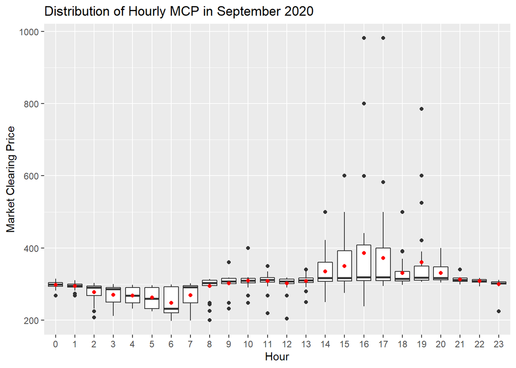

```r
ggplot(df_v2, aes(x = hour, y = MCP)) +
  geom_boxplot() +
  labs(x = "Hour",
       y = "Market Clearing Price",
       title = "Distribution of Hourly MCP in September 2020") +
  stat_summary(fun.y =mean, geom = "point", color="red")
```

1- The data shows that there are comparatively short box plots between 21:00 and 01:59 with a few outliers, which indicates that MCP is pretty much stable. This is the group with the lowest risk.

3- Between 08:00 and 12:59, there are again comparatively short box plots however, this time, there is a remarkable number of outliers, indicating that even if there are some outlying cases, most of the observations stays pretty much stable in a short range. This group is a bit riskier than the first group.

### Distribution of Penalty Percentage for Underestimated Consumption

Underestimated energy requirement would result in maximum of Market Clearing Price and System Marginal Price times Penalty(1.03). It’s called Negative Imbalance Price. Therefore, underestimating may have a huge cost for a consumer. In the following analysis, we examined how much a consumer would pay in addition to MCP in case of an underestimated energy consumption.

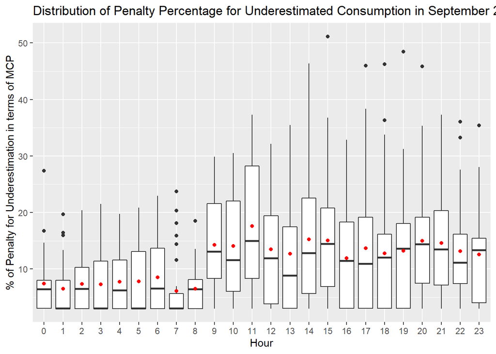

```r
df_pen <- df_v2 %>%
  mutate(pen_for_underest = (Neg_Imb_Price-MCP)*100/MCP)

ggplot(df_pen, aes(x = hour, y = pen_for_underest)) +
  geom_boxplot() +
  labs(x = "Hour",
       y = "% of Penalty for Underestimation in terms of MCP",
       title = "Distribution of Penalty Percentage for Underestimated Consumption in September 2020") +
  stat_summary(fun.y =mean, geom = "point", color="red")
```

The graph above reveals that on average, a consumer with underestimated energy consumption make additional payment of ~%5 of Market Clearing Price at 7:00 whereas the additional payment is ~%15 of MCP at 11:00. It highlights the fact that misestimation would cost more at 11:00 than at 7:00.

Between 09:00-23:59, the average percentage of penalty for underestimation and the standard deviation for the penalty is higher than the rest of the day. There is even a case where an underestimation was resulted in an additional payment of ~%50 MCP, %150 MCP in total. Therefore, it is better to avoid over consumption of energy within this period.

## Conclusion

While the first analysis was aimed at navigating the time plots for the cheapest energy consumption, the second analysis was aimed at navigating the time plots for bidding more conservative. The analysis emphasized that in order to avoid any huge price differences, it is better to be more aggressive in bidding for an additional hour for safety between 09:00 and 23:59.

All in all, it should be taken into consideration that the analysis is conducted based on the data for only September 2020. Therefore, our analysis may ignore any seasonality effect or the analysis may be under the influence of CoVID-19.

## Reference

EPIAS Market & Financial Settlement Center. MCP SMP and Imbalance Price Listing. Retrieved from: https://rapor.epias.com.tr/rapor/xhtml/ptfSmfListeleme.xhtml